# Rcourse_p2

Mirela Balan

Wed Sep 29 12:55:09 2021

#### **Load libraries**

```r
library(tidyverse)
library(DESeq2)
library(apeglm)
#library(dplyr)
library(ggplot2)
library(pheatmap)
library(knitr)
```

## **1. Quick recap** - 50 min

The steps required to do differential expression analysis using DESeq2 package (with default parameters): NOT RUN

```r
# make the DESeqDataSet (dds) object:
dds <- DESeqDataSetFromMatrix(countData = matrix_with_count_data,
                              colData = dataframe_with_sample_information,
                              design = what_variables_interest_you)

# explore data & QC: transform data, plot (PCA, heatmap)

# perform statistical analysis
dds <- DESeq(dds)

# extract results
res <- results(dds)
```

Things are a bit more complicated in reality - an interative process.

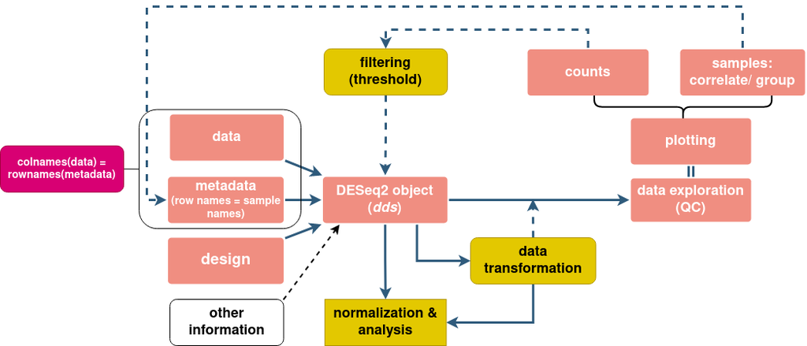

### **1.1. Load data, metadata, decide on design**

You have learned more about loading and fixing data, exploring it and creating a DESeq2 object in the previous day. Here the same steps are summarized and used to load the data for today’s lesson.

```r
#Loading data and metadata (sample sheet)
data <- read.table("../data/qc/counts_qc.tsv", header=TRUE, check.names = TRUE)
metadata <- read.table("../data/qc/counts_qc_meta.tsv", header=TRUE, check.names = TRUE, stringsAsFactor = F)
colnames(metadata) <- c("sample", "celltype", "condition")

metadata$celltype <- as.factor(metadata$celltype)    # observe the change from 'character' to 'factor'
metadata$condition <- as.factor(metadata$condition)
rownames(metadata) <- metadata$sample
head(data)
```

|  | JJ_CTRL_1 | BM_CTRL_2 | BM_CTRL_3 | BM_AMIL_1 | BM_AMIL_2 | BM_AMIL_3 | BM_CTRL_1 | JJ_CTRL_2 | JJ_CTRL_3 | JJ_AMIL_1 | JJ_AMIL_2 | JJ_AMIL_3 | BM_TG_1 | BM_TG_2 | BM_TG_3 | JJ_TG_1 | JJ_TG_2 | JJ_TG_3 |
| --- | --- | --- | --- | --- | --- | --- | --- | --- | --- | --- | --- | --- | --- | --- | --- | --- | --- | --- |
| ENSG00000000003 | 0 | 0 | 0 | 0 | 0 | 0 | 0 | 0 | 0 | 0 | 0 | 0 | 0 | 0 | 0 | 0 | 0 | 0 |
| ENSG00000000005 | 0 | 0 | 0 | 0 | 0 | 0 | 0 | 0 | 0 | 0 | 0 | 0 | 0 | 0 | 0 | 0 | 0 | 0 |
| ENSG00000000419 | 1637 | 1792 | 2368 | 2365 | 4808 | 2098 | 1664 | 1878 | 1367 | 1155 | 3020 | 3834 | 2461 | 1962 | 2417 | 1601 | 3110 | 2129 |
| ENSG00000000457 | 453 | 614 | 854 | 623 | 585 | 431 | 687 | 869 | 619 | 512 | 953 | 1049 | 845 | 757 | 859 | 823 | 1342 | 904 |
| ENSG00000000460 | 719 | 961 | 1280 | 937 | 1247 | 852 | 884 | 1058 | 616 | 840 | 1320 | 1161 | 1944 | 1528 | 2106 | 1350 | 2569 | 1654 |
| ENSG00000000938 | 2 | 3 | 6 | 0 | 0 | 0 | 1 | 4 | 1 | 3 | 3 | 5 | 5 | 1 | 3 | 2 | 2 | 3 |

```r
head(metadata)
```

|  | sample | celltype | condition |
| --- | --- | --- | --- |
| JJ_CTRL_1 | JJ_CTRL_1 | JJ | DMSO |
| BM_CTRL_2 | BM_CTRL_2 | BM | DMSO |
| BM_CTRL_3 | BM_CTRL_3 | BM | DMSO |
| BM_AMIL_1 | BM_AMIL_1 | BM | AMIL |
| BM_AMIL_2 | BM_AMIL_2 | BM | AMIL |
| BM_AMIL_3 | BM_AMIL_3 | BM | AMIL |

```r
#check if the col and rows are in the same order:
all(rownames(metadata) == colnames(data))
```

```
## [1] TRUE
```

#### **1.1.a. count data**

- usually named ‘data’, ‘counts’
- a matrix with **raw counts** - not normalized, not transformed; integers
- to explore: head(data), dim(data), str(data), summary(data)

#### **1.1.b. information about the samples**

- usually named ‘metadata’, ‘colData’
- dataframe with all known useful information about the samples: name, condition (control/treatment, WT/KO/KD/OE), batch/ sequencing day, gender, age
- to explore: head(metadata)
  - rows of the metadata should be named with sample names (important for downstream steps)
  - **column names of the data should be identical and in the same order with the row names of the metadata!**: `all(colnames(data)==rownames(metadata))` should output ‘TRUE’
- factorization!
  - used to represent categorical data
  - stored as integers that have associated labels: R sorts the labels alphabetically

    ```
    1    2    3
    AMIL DMSO TG
    ```

  - can be:
    - ordered: small < normal < large; sand < pebels < stones < boulders;
    - unordered: DMSO, TG, AMIL; WT, KO-1, KO-2;
  - levels = predefined factors; reference level = the 1st level
  - the order in which the factors are ordered matters:
    - for plotting:

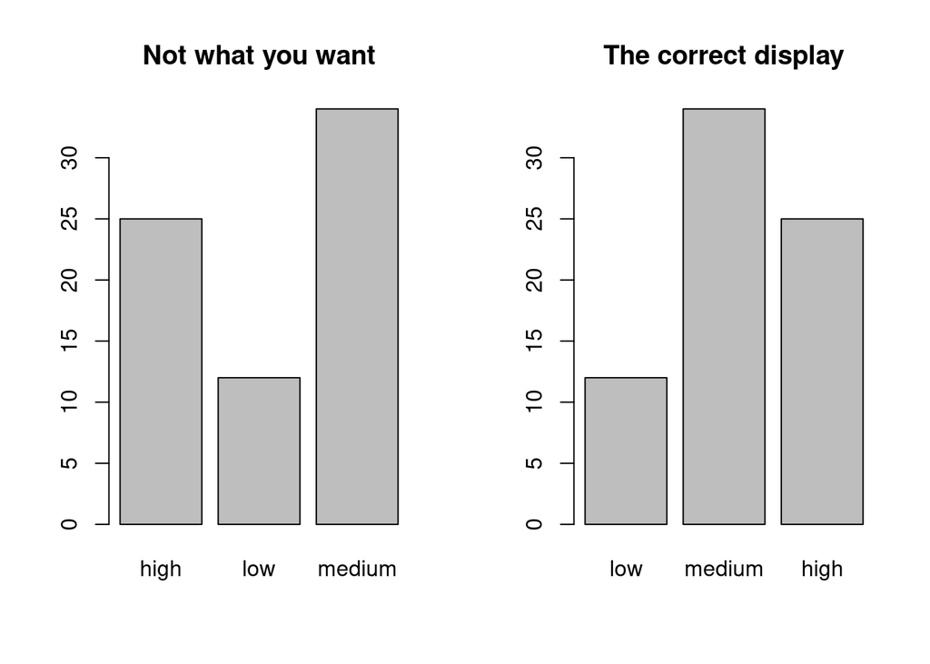

    - for statistics: for DE analysis, DESeq2 compares all other levels within a variable with the 1st level. So if they are mixed, instead of comparing ‘treatment1 to control’ and ‘treatment2 to control’, you might end up with unexpected results!

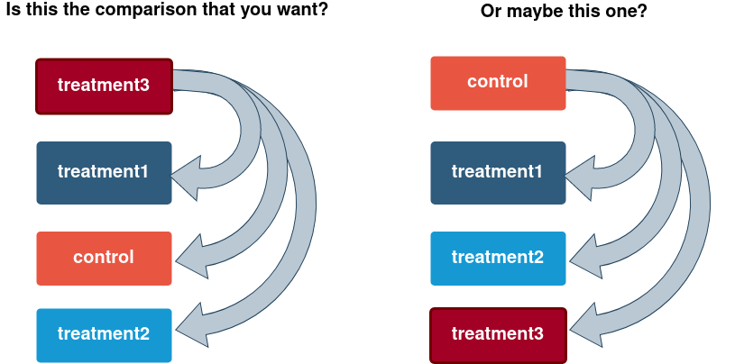

- how to reorder factors: NOT RUN

```r
# in the metadata dataframe
metadata$condition <- factor(metadata$condition, levels = c ('DMSO', 'AMIL', 'TG'))

# in the dds object
dds$condition <- relevel(dds$condition, ref='DMSO')   # if you only care about what is the reference level

# or
dds$condition <- factor(dds$condition, levels = c ('DMSO', 'AMIL', 'TG'))  # if you want a specific order for all of them

# not reorder your factors, but then you have to use the 'contrast' arguments in the results() function
```

Back to our data. This is the order of the factors before and after re-arrangement:

```r
#initial factor arrangement:
metadata$condition
```

```
##  [1] DMSO DMSO DMSO AMIL AMIL AMIL DMSO DMSO DMSO AMIL AMIL AMIL TG   TG   TG
## [16] TG   TG   TG
## Levels: AMIL DMSO TG
```

```r
#rearrange factors
metadata$condition <- factor(metadata$condition, levels = c("DMSO", "AMIL", "TG"))

metadata$condition
```

```
##  [1] DMSO DMSO DMSO AMIL AMIL AMIL DMSO DMSO DMSO AMIL AMIL AMIL TG   TG   TG
## [16] TG   TG   TG
## Levels: DMSO AMIL TG
```

#### **1.1.c. experimental design**

- contains variables which will be used in data modeling for estimating dispersions and the log fold changes.
- formula:
  - starts with a tilde ‘~’
  - the names used are the names of the columns of the metadata
  - add the needed variables, with the one you are most interested in explaining at the end
    - e.g. ‘~ batch + condition’ = measure the effect of condition, while controlling for batch-induced differences
  - make sure the control condition (e.g. DMSO, WT, PBS) is the reference level

```r
design <- ~ celltype + condition
```

All that is left now is to make the dds object:

```r
dds_old <- DESeqDataSetFromMatrix(countData=data, colData=metadata, design=design)
```

- dds object stores:
  - read counts (data) - call it with `counts(dds)`
  - sample info (metadata) - call it with `colData(dds)`
  - intermediate estimated quantities - during statistical analysis
  - more additional features that you can add manually to the metadata columns of a newly constructed object: `mcols(dds) <- DataFrame(mcols(dds), my_dataframe)`

### **1.2. Exploring data - part 1**

Previously you noticed that the PCA shows a problem with our data. The dataset you are working on has been changed for the purpose of teaching you data exploration. But you might find this kind of issue in datasets without them being tampered.

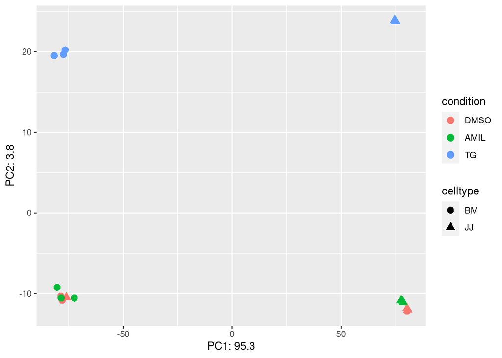

Let’s fix the dataset, to return it to the way the data was originally published:

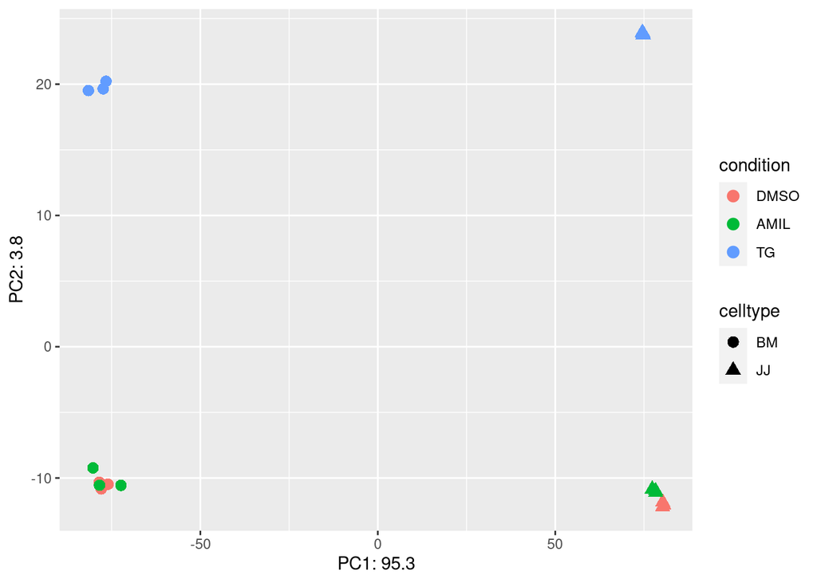

```r
#Fix data:
#switch rows 1 and 7 in metadata
metadata <- metadata[c(7, 2:6, 1, 8:nrow(metadata)),]
rownames(metadata) <- metadata$sample    # needed for plotting with pheatmap
#metadata$sample <- NULL    #if you want to remove the 'sample' column

#switch column names in counts:
colnames(data)[c(1,7)] <- c("BM_CTRL_1", "JJ_CTRL_1")

#check if the col and rows are in the same order:
all(rownames(metadata) == colnames(data))

#new PCA
design <- ~ celltype + condition        #!!! names must be the same as the columns in the metadata file!!!
dds <- DESeqDataSetFromMatrix(countData=data, colData=metadata, design=design)
rld <- plotPCA(rlog(dds, blind = TRUE), intgroup=c("condition", "celltype"), returnData=TRUE)  # 'plotPCA' is a DESeq2 function used for plotting transformed data; can use ggplot code you learned yesterday
percentVar <- round(100 * attr(rld, "percentVar"), 1)   # rounded values for each axis of PC variance

ggplot(rld, aes(PC1, PC2, color=condition, shape=celltype)) +
  geom_point(size=3) +
  xlab(paste0("PC1: ",percentVar[1])) +
  ylab(paste0("PC2: ",percentVar[2]))
```

You can see that now the samples group nicely on the PCA.

**Q1**: What would you do if you find yourself in the situation where there is something wrong in your dataset? Would you drop the responsible sample? Would you modify the dataset? How would you make that choice?

## **2. Data exploration, visualization and QC** - 30 min

After creating the DESeq2 object, you need to explore your data further to learn more about it, to check if your expectations are met. Also, the downstream analyses rely on a couple of assumptions and we need to see to what degree our data match those assumptions, and to correct it if possible. Also, to create informative, easy to interpret visualizations, the data needs to be transformed before plotting. We need to talk about: - filtering - distributions for data modeling: mean, stdvar, variance, dispersion, overdispersion - transformations: log, vst, rlog

### **2.1. Data pre-filtering**

Let’s look at our data using the ‘summary()’ function:

```r
summary(counts(dds))[,1:3]  #shows the summary only for the first 3 samples - for brevity
```

```
##    BM_CTRL_1         BM_CTRL_2         BM_CTRL_3
##  Min.   :      0   Min.   :      0   Min.   :       0
##  1st Qu.:      0   1st Qu.:      0   1st Qu.:       0
##  Median :      0   Median :      0   Median :       0
##  Mean   :    747   Mean   :   1007   Mean   :    1248
##  3rd Qu.:     11   3rd Qu.:     14   3rd Qu.:      18
##  Max.   :7019288   Max.   :9370725   Max.   :11703125
```

**Q2**: notice the output - what do the various parameters tell you about the data? What does the ‘mean’ tell you, practically?

- several types of filtering, some manual others automatic
- the pre-filtering is helpful but not necessary to remove rows/genes that have very low counts (very unlikely to have biological meaning)
  - arbitrary threshold: < 1, < 10
  - reduces the memory size that the ‘dds’ object occupies => increases the speed of transformations and calculations
  - reduces the numbers of comparisons done when testing for significance => improves the outcomes

```r
#decide on the threshold you want to use  (= the minimum number of counts you want to keep)
keep <- rowSums(counts(dds)) > 1
cat('genes before filter: ', nrow(dds), '\n')    # prints the number of rows you have before the filtering
```

```
## genes before filter:  57910
```

```r
# keep the desired rows
fdds <- dds[keep, ]                               # most people keep the 'dds' name, but I will change it to help you differentiate between the different steps and learn. But doing this will fill up your memory.
cat('genes before filter: ', nrow(fdds), '\n')    # prints the number of rows you have after the filtering
```

```
## genes before filter:  27573
```

Notice how many rows you have dropped. In this case you are left only with **47.61 %** of the initial number of rows!

NOTE1: the threshold depends on the dataset, your goals and the R package you use. With DESeq2 it is recommended to only do a minimal filtering to remove the zero counts. This is because the later analysis will apply their own automatic filtering, such as when using the ‘results()’ function from DESeq2.

NOTE2: If you have an unequal number of samples in the groups, you should set the minimal number of samples in which the counts should be above a certain value. For example, if your smallest group has only 5 samples and the others more, and you want a stricter threshold (of lets say 10 counts), use the filtering as such: `keep <- rowSums(counts(dds) >= 10) >= 5`

### **2.2. Modeling count data**

An important step in DE analysis is to model the association between gene counts and covariates of interest = find the (cluster of) genes that significantly change their expression, that can be attributed to a combination of factors outlined in your experimental design.

- data can be modeled with various distributions depending on their properties:
- terms:
  - mean of the group: the average value of a sample
  - variance: the expectation of the squared deviation (stdev^2) of a variable from its population mean. It is a measure of dispersion (of how far a set of numbers is spread out from their average value)

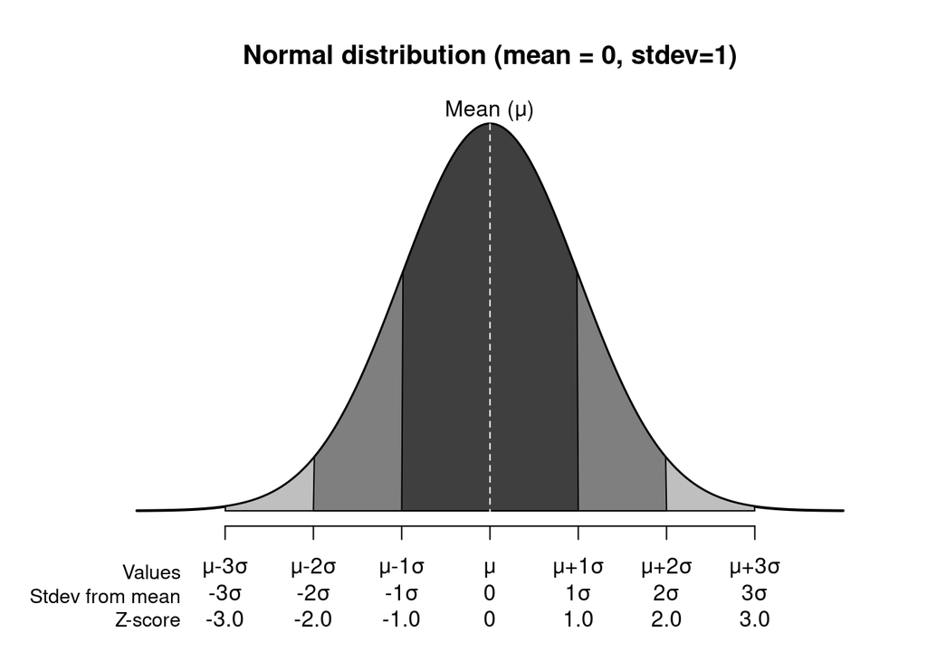

```r
x <- seq(-4, 4, length=200)
y <- dnorm(x, mean=0, sd=1)

plot(x, y, type="l", lwd=2,  axes=FALSE, ann = FALSE)  #  scatterplot with connected lines (type = "l"); remove axes and the axes titles
title ("Normal distribution (mean = 0, stdev=1)", cex=0.8)

#choose the colors for the plot:
custom_grey_pallete <- colorRampPalette(c("grey0", "grey100"))
my_colors <- custom_grey_pallete(5)

i <- x >= -3 & x <= 3
#lines(x, y)
polygon(c(-3,x[i],3), c(0,y[i],0), col=my_colors[4])

i <- x >= -2 & x <= 2
polygon(c(-2,x[i],2), c(0,y[i],0), col=my_colors[3])

i <- x >= -1 & x <= 1
polygon(c(-1,x[i],1), c(0,y[i],0), col=my_colors[2])

abline(v = 0, lty=2, col='white')

# Display text on the plot. The default "side" parameter is 3, representing the top of the plot.
mtext("Mean (μ)", side = 3, line=-0.5)


# add multiple labels to the axis
mtext('Values\nStdev from mean\n Z-score', side =1,
      line = 3,
      at = -3.5, adj=1, cex=0.9)

axis(1, at=seq(-3, 3, by=1), labels=c("μ-3σ", "μ-2σ", "μ-1σ", "μ", "μ+1σ", "μ+2σ", "μ+3σ"), cex=0.9)
axis(1, at=seq(-3, 3, by=1), labels=c('-3σ', '-2σ', '-1σ', '0', '1σ', '2σ', '3σ'), line=1, tick = FALSE, cex=0.9)
axis(1, at=seq(-3, 3, by=1), labels=c('-3.0', '-2.0', '-1.0', '0', '1.0', '2.0', '3.0'), line=2, tick = FALSE, cex=0.9)
```

```r
### remember: value of z-score: z=(value-mean)/sigma
```

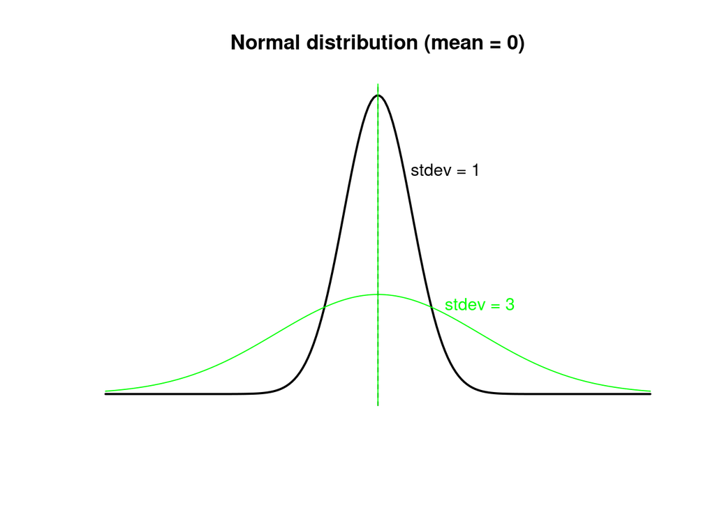

```r
x <- seq(-8, 8, length=200)
y <- dnorm(x, mean=0, sd=1)
z <- dnorm(x, mean=0, sd=3)

plot(x, y, type="l", lwd=2,  axes=FALSE, ann = FALSE )  #  scatterplot with connected lines (type = "l"); remove axes and the axes titles
title ("Normal distribution (mean = 0)", cex=0.8)
lines(x,z,col="green")

#legend("topright", legend=c('stdev=1', 'stdev=3'), col=c('black', 'green'))

abline(v = 0, lty=2, col='black')
abline(v = 0, lty=1, col='green')
text(2, 0.3, labels="stdev = 1", col = 'black')
text(3, 0.12, labels="stdev = 3", col = 'green')
```

- RNAseq data is: - discrete (counts) - very large number of RNAs are represented and the probability of pulling out a particular transcript is very small - Poisson? (assumes that mean = variance) - Binomial? (assumes that mean > variance)

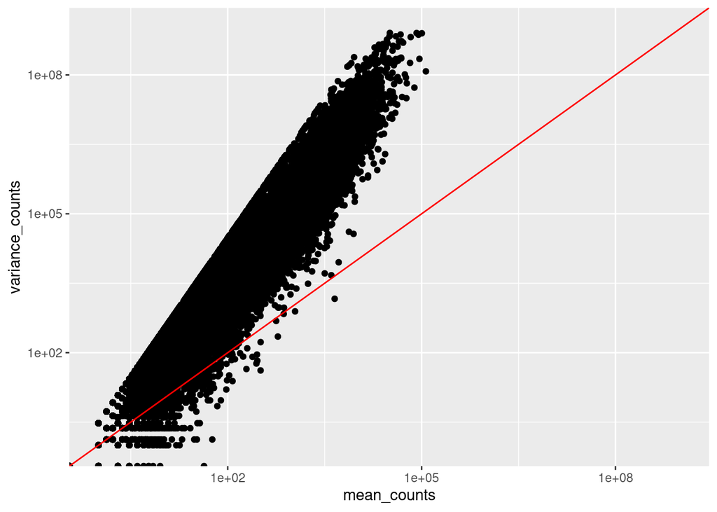

```r
#overdispersion
mean_counts <- apply(counts(dds)[,6:8], 1, mean)        # '1' means that the function 'apply' is applied to rows. Use '2' if applied to columns
variance_counts <- apply(counts(dds)[,6:8], 1, var)
df <- data.frame(mean_counts, variance_counts)

ggplot(df) +
        geom_point(aes(x=mean_counts, y=variance_counts)) +
        scale_y_log10(limits = c(1,1e9)) +
        scale_x_log10(limits = c(1,1e9)) +
        geom_abline(intercept = 0, slope = 1, color="red")
```

We observe from above that mean < variance => we should use a **negative binomial** distribution

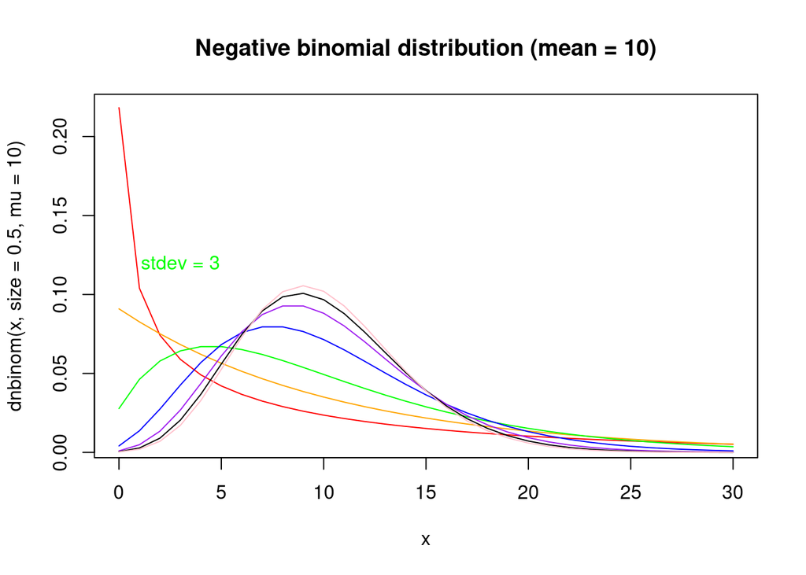

```r
x <- 0:30

plot(x, dnbinom(x, size=0.5, mu=10), type = "l", col='red')
lines(x, dnbinom(x, size=1, mu=10), type = "l", col='orange')
lines(x, dnbinom(x, size=2, mu=10), type = "l", col='green')
lines(x, dnbinom(x, size=5, mu=10), type = "l", col='blue')
lines(x, dnbinom(x, size=10, mu=10), type = "l", col='purple')
lines(x, dnbinom(x, size=15, mu=10), type = "l", col='black')
lines(x, dnbinom(x, size=20, mu=10), type = "l", col='pink')

title ("Negative binomial distribution (mean = 10)", cex=0.8)
text(2, 0.3, labels="stdev = 1", col = 'black')
text(3, 0.12, labels="stdev = 3", col = 'green')
```

### **2.3. Data transformation**

DESeq2 needs as input **raw counts** for statistical testing, but for some stages of visualization or downstream analysis, you need **transformed data**. Methods of exploratory analysis of multidimensional data work best for data that has in general the same range of variance at different ranges of the mean values (also called **homoskedastic data**). We just saw that mRNA data is **heteroskedastic** (variance grows with the mean), so if we plot that data, the biggest difference will be given by the genes with the highest counts because they show the largest absolute differences between samples.

1. logarithmic data - also called **pseudocounts**; used mostly in visualization because of the large dynamic range of the data; the logarithmic function is of the type: log2(count+n0), usually log2(count+1). The ‘n0’ value is a positive constant that is introduced because of the zero counts (log(0) tends to infinity and this introduces other issues in the visualization). The problem is that the genes with the very lowest counts (which also have a very poor noise-to-signal ratio) contribute the greatest amount the noise (log of small numbers inflates their variance) = **the low counts genes will overly contribute to sample-sample distances**. We need to stabilize the variance across the mean, for which we can use:

```r
print('dataset with counts before transformation (raw counts):' )
```

```
## [1] "dataset with counts before transformation (raw counts):"
```

```r
head(counts(fdds),3)
```

```
##                 BM_CTRL_1 BM_CTRL_2 BM_CTRL_3 BM_AMIL_1 BM_AMIL_2 BM_AMIL_3
## ENSG00000000419      1637      1792      2368      2365      4808      2098
## ENSG00000000457       453       614       854       623       585       431
## ENSG00000000460       719       961      1280       937      1247       852
##                 JJ_CTRL_1 JJ_CTRL_2 JJ_CTRL_3 JJ_AMIL_1 JJ_AMIL_2 JJ_AMIL_3
## ENSG00000000419      1664      1878      1367      1155      3020      3834
## ENSG00000000457       687       869       619       512       953      1049
## ENSG00000000460       884      1058       616       840      1320      1161
##                 BM_TG_1 BM_TG_2 BM_TG_3 JJ_TG_1 JJ_TG_2 JJ_TG_3
## ENSG00000000419    2461    1962    2417    1601    3110    2129
## ENSG00000000457     845     757     859     823    1342     904
## ENSG00000000460    1944    1528    2106    1350    2569    1654
```

```r
print('dataset with counts after logarithmic transformation:' )
```

```
## [1] "dataset with counts after logarithmic transformation:"
```

```r
head(log(counts(fdds), 2) ,3)
```

```
##                 BM_CTRL_1 BM_CTRL_2 BM_CTRL_3 BM_AMIL_1 BM_AMIL_2 BM_AMIL_3
## ENSG00000000419 10.676839 10.807355 11.209453 11.207624 12.231221 11.034799
## ENSG00000000457  8.823367  9.262095  9.738092  9.283088  9.192293  8.751544
## ENSG00000000460  9.489848  9.908393 10.321928  9.871905 10.284246  9.734710
##                 JJ_CTRL_1 JJ_CTRL_2 JJ_CTRL_3 JJ_AMIL_1 JJ_AMIL_2 JJ_AMIL_3
## ENSG00000000419 10.700440 10.874981 10.416798 10.173677 11.560333  11.90463
## ENSG00000000457  9.424166  9.763212  9.273796  9.000000  9.896332  10.03480
## ENSG00000000460  9.787903 10.047124  9.266787  9.714246 10.366322  10.18115
##                   BM_TG_1   BM_TG_2   BM_TG_3   JJ_TG_1  JJ_TG_2   JJ_TG_3
## ENSG00000000419 11.265029 10.938109 11.239002 10.644758 11.60270 11.055960
## ENSG00000000457  9.722808  9.564149  9.746514  9.684749 10.39017  9.820179
## ENSG00000000460 10.924813 10.577429 11.040290 10.398744 11.32699 10.691744
```

2. variance stabilizing transformations (VTS) - for negative binomial data with a dispersion-mean trend. Faster and much less sensitive to high count outliers that ‘rlog’ transformation. Use for medium-large datasets (n>30). On the plot, you can see an upward shift for the smaller values

```r
print('dataset with counts after VTS transformation:' )
```

```
## [1] "dataset with counts after VTS transformation:"
```

```r
vsd <- vst(fdds, blind = FALSE)  # 'blind=FALSE' means that differences between cell lines and treatment (the variables in the design) will not contribute to the expected variance-mean trend of the experiment. The experimental design is not used directly in the transformation, only in estimating the global amount of variability in the counts. For a fully unsupervised transformation, one can set blind = TRUE
head(assay(vsd),3)
```

```
##                 BM_CTRL_1 BM_CTRL_2 BM_CTRL_3 BM_AMIL_1 BM_AMIL_2 BM_AMIL_3
## ENSG00000000419 10.937809 10.614770 10.704890 11.053188 11.886770 11.290920
## ENSG00000000457  9.165370  9.143968  9.298534  9.208782  8.962377  9.101161
## ENSG00000000460  9.791242  9.750070  9.849072  9.761955  9.986720 10.027242
##                 JJ_CTRL_1 JJ_CTRL_2 JJ_CTRL_3 JJ_AMIL_1 JJ_AMIL_2 JJ_AMIL_3
## ENSG00000000419 11.063512 10.852155 10.982490 10.752128  11.40779 11.607554
## ENSG00000000457  9.828526  9.779397  9.876654  9.623497   9.79329  9.790438
## ENSG00000000460 10.176797 10.050510  9.869970 10.306367  10.24348  9.929952
##                   BM_TG_1   BM_TG_2  BM_TG_3  JJ_TG_1  JJ_TG_2   JJ_TG_3
## ENSG00000000419 11.102571 11.074476 11.02025 11.01074 11.23012 11.176696
## ENSG00000000457  9.614058  9.746278  9.58165 10.07938 10.05183  9.977406
## ENSG00000000460 10.770003 10.722121 10.82604 10.77043 10.95997 10.820328
```

3. regularized logarithm (RLOG) - slower because it requires fitting a shrinkage term for each sample and each gene. Works well for small datasets (n < 30) and when there is a wide range of sequencing depth across samples (an order of magnitude difference).

```r
print('dataset with counts after RLOG transformation:' )
```

```
## [1] "dataset with counts after RLOG transformation:"
```

```r
rld <- rlog(fdds, blind = FALSE)
head(assay(rld),3)
```

```
##                 BM_CTRL_1 BM_CTRL_2 BM_CTRL_3 BM_AMIL_1 BM_AMIL_2 BM_AMIL_3
## ENSG00000000419 10.906378 10.577978 10.669765 11.023248 11.862797 11.263470
## ENSG00000000457  9.055874  9.032893  9.197776  9.102205  8.837395  8.987074
## ENSG00000000460  9.722432  9.679472  9.782542  9.691870  9.925347  9.967295
##                 JJ_CTRL_1 JJ_CTRL_2 JJ_CTRL_3 JJ_AMIL_1 JJ_AMIL_2 JJ_AMIL_3
## ENSG00000000419  11.03370 10.819474 10.951665 10.717867 11.381314 11.582374
## ENSG00000000457   9.75469  9.703564  9.804695  9.540657  9.718042  9.715077
## ENSG00000000460  10.12159  9.991331  9.804349 10.254771 10.190182  9.866534
##                   BM_TG_1   BM_TG_2   BM_TG_3  JJ_TG_1   JJ_TG_2   JJ_TG_3
## ENSG00000000419 11.073213 11.044792 10.989899 10.98028 11.202113 11.148145
## ENSG00000000457  9.530771  9.669029  9.496775 10.01458  9.986201  9.909197
## ENSG00000000460 10.728235 10.679524 10.785169 10.72864 10.921053 10.779354
```

- 2. and c) have similar properties. For high counts, the results are similar to the logarithmic transformation. But for low counts, the values are shrunken towards a middle value. This makes the data behave more like homoskedastic data. We can see the differences in plots. . Sequencing depth correction is done automatically for the vst and rlog.

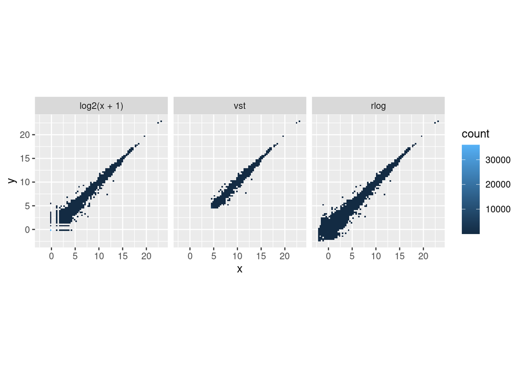

```r
dds <- estimateSizeFactors(dds) # needed for log2 approach to account for sequencing depth

df <- bind_rows(
  as_tibble(log2(counts(dds, normalized=TRUE)[, 1:2]+1)) %>%
         mutate(transformation = "log2(x + 1)"),
  as_tibble(assay(vsd)[, 1:2]) %>% mutate(transformation = "vst"),          # normalization and size factors not needed - automatically detected
  as_tibble(assay(rld)[, 1:2]) %>% mutate(transformation = "rlog"))

colnames(df)[1:2] <- c("x", "y")

lvls <- c("log2(x + 1)", "vst", "rlog")
df$transformation <- factor(df$transformation, levels=lvls)

ggplot(df, aes(x = x, y = y)) + geom_bin2d(bins=80) +
  coord_fixed() + facet_grid( . ~ transformation)
```

Does it make a difference to the visualizations?

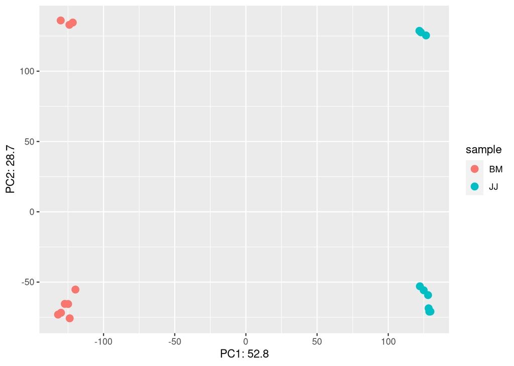

```r
# th <- data.frame(round(log(counts(fdds)+1)))
#
# ldds <- DESeqDataSetFromMatrix(countData=th, colData=metadata, design=design)

th <- data.frame(round(log(counts(fdds)+1)))

th.pca <- prcomp(t(th))
pca_data_perc=round(100*th.pca$sdev^2/sum(th.pca$sdev^2),1)

df_pca_data=data.frame(PC1 = th.pca$x[,1], PC2 = th.pca$x[,2], sample = metadata$celltype, condition=metadata$celltype)  #! change condition accordingly!


ggplot(df_pca_data, aes(PC1, PC2, color=sample)) +
  geom_point(size=3) +
  xlab(paste0("PC1: ",pca_data_perc[1])) +
  ylab(paste0("PC2: ",pca_data_perc[2]))
```

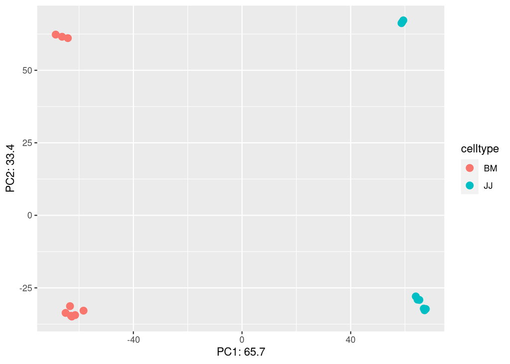

```r
#############################
rld_new2 <- plotPCA(vst(fdds, blind = TRUE), intgroup='celltype', returnData=TRUE)  # 'plotPCA' is a DESeq2 function used for plotting transformed data; can use ggplot code you learned yesterday
percentVar <- round(100 * attr(rld_new2, "percentVar"), 1)   # rounded values for each axis of PC variance

ggplot(rld_new2, aes(PC1, PC2, color=celltype)) +
  geom_point(size=3) +
  xlab(paste0("PC1: ",percentVar[1])) +
  ylab(paste0("PC2: ",percentVar[2]))
```

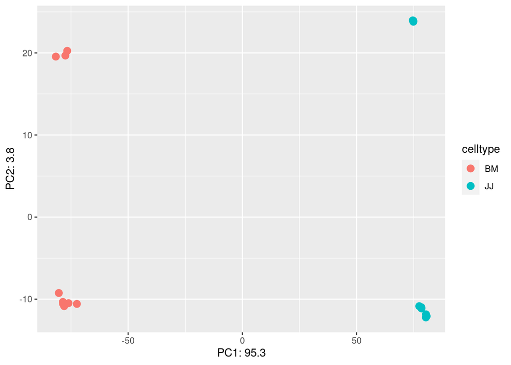

```r
#############################
rld_new3 <- plotPCA(rlog(fdds, blind = TRUE), intgroup='celltype', returnData=TRUE)  # 'plotPCA' is a DESeq2 function used for plotting transformed data; can use ggplot code you learned yesterday
percentVar <- round(100 * attr(rld_new3, "percentVar"), 1)   # rounded values for each axis of PC variance

ggplot(rld_new3, aes(PC1, PC2, color=celltype)) +
  geom_point(size=3) +
  xlab(paste0("PC1: ",percentVar[1])) +
  ylab(paste0("PC2: ",percentVar[2]))
```

```r
##ref: https://www.biostars.org/p/289333/
```

## **3. Differential expression analysis** - 30 min

The results can be returned using the standard function:

```r
dds <- DESeq(dds)
```

There are several steps to generating the DE results, and they are wrapped together in the **DESeq()** function. The 3 main steps are estimations of: - estimating size factors - estimating dispersions - fitting model and testing

### **3.1. Size factors**

The libraries have different sizes, so when using data for statistical analysis, you must have comparable libraries for the downstream estimations = normalization. The size factors are meant to account for the different sequencing depths.

```r
colSums(counts(dds))
```

```
## BM_CTRL_1 BM_CTRL_2 BM_CTRL_3 BM_AMIL_1 BM_AMIL_2 BM_AMIL_3 JJ_CTRL_1 JJ_CTRL_2
##  43280483  58322866  72279980  52133518  60340209  41801833  42113155  54547922
## JJ_CTRL_3 JJ_AMIL_1 JJ_AMIL_2 JJ_AMIL_3   BM_TG_1   BM_TG_2   BM_TG_3   JJ_TG_1
##  36712089  33538583  54875554  59313156  44307825  36758077  47308090  33683395
##   JJ_TG_2   JJ_TG_3
##  55031884  38803467
```

‘DESeq()’ function estimates size factors automatically. But if you run `estimateSizeFactors()` before the `DESeq()` functions, these values would be used instead.

```r
dds <- estimateSizeFactors(dds)
sizeFactors(dds)
```

```
## BM_CTRL_1 BM_CTRL_2 BM_CTRL_3 BM_AMIL_1 BM_AMIL_2 BM_AMIL_3 JJ_CTRL_1 JJ_CTRL_2
## 0.8537646 1.1759096 1.4572461 1.1366414 1.2847050 0.8523922 0.7939116 1.0408277
## JJ_CTRL_3 JJ_AMIL_1 JJ_AMIL_2 JJ_AMIL_3   BM_TG_1   BM_TG_2   BM_TG_3   JJ_TG_1
## 0.6907236 0.6872827 1.1299355 1.2463471 1.1421656 0.9288558 1.1890425 0.7929294
##   JJ_TG_2   JJ_TG_3
## 1.3189577 0.9376383
```

- the larger size factors correspond to the samples with higher sequencing depth.
- to generate the normalized counts we need to divide the counts by the size factors.

Now, see the changes in the values of the library sizes:

```r
colSums(counts(dds, normalized=T))
```

```
## BM_CTRL_1 BM_CTRL_2 BM_CTRL_3 BM_AMIL_1 BM_AMIL_2 BM_AMIL_3 JJ_CTRL_1 JJ_CTRL_2
##  50693697  49598087  49600393  45866284  46968144  49040607  53045141  52408217
## JJ_CTRL_3 JJ_AMIL_1 JJ_AMIL_2 JJ_AMIL_3   BM_TG_1   BM_TG_2   BM_TG_3   JJ_TG_1
##  53150190  48798816  48565207  47589596  38792821  39573502  39786711  42479688
##   JJ_TG_2   JJ_TG_3
##  41723766  41384262
```

### **3.2. Dispersions**

DESeq2 measures variation using the term ‘dispersion’, that actually connects a gene’s variance and mean expression level. Dispersion is calculated by `Var = μ + α*μ^2`, where `α` = dispersion, `Var` = variance, and `μ` = mean

```r
dds <- estimateDispersions(dds)
```

DESeq2 has a function that allows to visualize the dispersion in your analysis

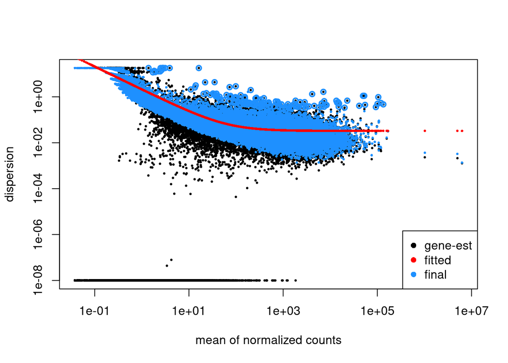

```r
plotDispEsts(dds)
```

- gene-wise dispersion by fitting a negative binomial general linear model (GLM) to the data and then returning the results using Wald statistics (**nbinomWaldTest**)

```r
dds <- DESeq(dds)
```

## **4. Extracting results**

```r
dds_res <- results(dds)
dds_res
```

```
## log2 fold change (MLE): condition TG vs DMSO
## Wald test p-value: condition TG vs DMSO
## DataFrame with 57910 rows and 6 columns
##                         baseMean log2FoldChange     lfcSE       stat
##                        <numeric>      <numeric> <numeric>  <numeric>
## ENSG00000000003            0.000             NA        NA         NA
## ENSG00000000005            0.000             NA        NA         NA
## ENSG00000000419         2200.383       0.243946 0.1543350    1.58063
## ENSG00000000457          748.393       0.344875 0.0747174    4.61572
## ENSG00000000460         1233.810       0.927522 0.0833622   11.12640
## ...                          ...            ...       ...        ...
## __no_feature             5018526     -1.0506457 0.0474806 -22.127909
## __ambiguous              1017561      0.0494678 0.0505125   0.979318
## __too_low_aQual                0             NA        NA         NA
## __not_aligned                  0             NA        NA         NA
## __alignment_not_unique   6286344     -1.3379050 0.0307255 -43.543795
##                              pvalue         padj
##                           <numeric>    <numeric>
## ENSG00000000003                  NA           NA
## ENSG00000000005                  NA           NA
## ENSG00000000419         1.13963e-01  2.08477e-01
## ENSG00000000457         3.91737e-06  2.08064e-05
## ENSG00000000460         9.33308e-29  2.32344e-27
## ...                             ...          ...
## __no_feature           1.70294e-108 1.65657e-106
## __ambiguous             3.27423e-01  4.76431e-01
## __too_low_aQual                  NA           NA
## __not_aligned                    NA           NA
## __alignment_not_unique  0.00000e+00  0.00000e+00
```